# Risk Factor Analysis

## Outcome Variable

**Outcome Variable:** pers_wasted624

## Predictor Variables

**Intervention Variable:** ever_co06

**Adjustment Set:**

unadjusted

## Stratifying Variables

The analysis was stratified on these variable(s):

- studyid
- country

## Data Summary

| studyid | country | ever_co06 | pers_wasted624 | n_cell | n |
| --- | --- | --- | --- | --- | --- |
| ki0047075b-MAL-ED | BANGLADESH | 0 | 0 | 215 | 240 |
| ki0047075b-MAL-ED | BANGLADESH | 0 | 1 | 16 | 240 |
| ki0047075b-MAL-ED | BANGLADESH | 1 | 0 | 7 | 240 |
| ki0047075b-MAL-ED | BANGLADESH | 1 | 1 | 2 | 240 |
| ki0047075b-MAL-ED | BRAZIL | 0 | 0 | 200 | 202 |
| ki0047075b-MAL-ED | BRAZIL | 0 | 1 | 2 | 202 |
| ki0047075b-MAL-ED | BRAZIL | 1 | 0 | 0 | 202 |
| ki0047075b-MAL-ED | BRAZIL | 1 | 1 | 0 | 202 |
| ki0047075b-MAL-ED | INDIA | 0 | 0 | 196 | 234 |
| ki0047075b-MAL-ED | INDIA | 0 | 1 | 21 | 234 |
| ki0047075b-MAL-ED | INDIA | 1 | 0 | 10 | 234 |
| ki0047075b-MAL-ED | INDIA | 1 | 1 | 7 | 234 |
| ki0047075b-MAL-ED | NEPAL | 0 | 0 | 227 | 234 |
| ki0047075b-MAL-ED | NEPAL | 0 | 1 | 1 | 234 |
| ki0047075b-MAL-ED | NEPAL | 1 | 0 | 5 | 234 |
| ki0047075b-MAL-ED | NEPAL | 1 | 1 | 1 | 234 |
| ki0047075b-MAL-ED | PERU | 0 | 0 | 261 | 264 |
| ki0047075b-MAL-ED | PERU | 0 | 1 | 2 | 264 |
| ki0047075b-MAL-ED | PERU | 1 | 0 | 1 | 264 |
| ki0047075b-MAL-ED | PERU | 1 | 1 | 0 | 264 |
| ki0047075b-MAL-ED | SOUTH AFRICA | 0 | 0 | 252 | 258 |
| ki0047075b-MAL-ED | SOUTH AFRICA | 0 | 1 | 2 | 258 |
| ki0047075b-MAL-ED | SOUTH AFRICA | 1 | 0 | 4 | 258 |
| ki0047075b-MAL-ED | SOUTH AFRICA | 1 | 1 | 0 | 258 |
| ki0047075b-MAL-ED | TANZANIA, UNITED REPUBLIC OF | 0 | 0 | 240 | 244 |
| ki0047075b-MAL-ED | TANZANIA, UNITED REPUBLIC OF | 0 | 1 | 0 | 244 |
| ki0047075b-MAL-ED | TANZANIA, UNITED REPUBLIC OF | 1 | 0 | 4 | 244 |
| ki0047075b-MAL-ED | TANZANIA, UNITED REPUBLIC OF | 1 | 1 | 0 | 244 |
| ki1000107-Serrinha-VitA | BRAZIL | 0 | 0 | 10 | 11 |
| ki1000107-Serrinha-VitA | BRAZIL | 0 | 1 | 1 | 11 |

[output cut: 126 more lines]

The following strata were considered:

- studyid: ki0047075b-MAL-ED, country: BANGLADESH
- studyid: ki0047075b-MAL-ED, country: BRAZIL
- studyid: ki0047075b-MAL-ED, country: INDIA
- studyid: ki0047075b-MAL-ED, country: NEPAL
- studyid: ki0047075b-MAL-ED, country: PERU
- studyid: ki0047075b-MAL-ED, country: SOUTH AFRICA
- studyid: ki0047075b-MAL-ED, country: TANZANIA, UNITED REPUBLIC OF
- studyid: ki1000107-Serrinha-VitA, country: BRAZIL
- studyid: ki1000108-CMC-V-BCS-2002, country: INDIA
- studyid: ki1000108-IRC, country: INDIA
- studyid: ki1000109-EE, country: PAKISTAN
- studyid: ki1000109-ResPak, country: PAKISTAN
- studyid: ki1000304-VITAMIN-A, country: INDIA
- studyid: ki1000304b-SAS-CompFeed, country: INDIA
- studyid: ki1000304b-SAS-FoodSuppl, country: INDIA
- studyid: ki1017093-NIH-Birth, country: BANGLADESH
- studyid: ki1017093b-PROVIDE, country: BANGLADESH
- studyid: ki1017093c-NIH-Crypto, country: BANGLADESH
- studyid: ki1033518-iLiNS-DYAD-G, country: GHANA
- studyid: ki1066203-TanzaniaChild2, country: TANZANIA, UNITED REPUBLIC OF
- studyid: ki1101329-Keneba, country: GAMBIA
- studyid: ki1112895-Burkina Faso Zn, country: BURKINA FASO
- studyid: ki1112895-Guatemala BSC, country: GUATEMALA
- studyid: ki1113344-GMS-Nepal, country: NEPAL
- studyid: ki1114097-CMIN, country: BANGLADESH
- studyid: ki1114097-CMIN, country: BRAZIL
- studyid: ki1114097-CMIN, country: GUINEA-BISSAU
- studyid: ki1114097-CMIN, country: PERU
- studyid: ki1114097-CONTENT, country: PERU
- studyid: ki1119695-PROBIT, country: BELARUS
- studyid: ki1126311-ZVITAMBO, country: ZIMBABWE
- studyid: ki1135781-COHORTS, country: GUATEMALA
- studyid: ki1135781-COHORTS, country: INDIA
- studyid: ki1135781-COHORTS, country: PHILIPPINES
- studyid: ki1148112-iLiNS-DOSE, country: MALAWI
- studyid: ki1148112-iLiNS-DYAD-M, country: MALAWI
- studyid: ki1148112-LCNI-5, country: MALAWI
- studyid: kiGH5241-JiVitA-3, country: BANGLADESH
- studyid: kiGH5241-JiVitA-4, country: BANGLADESH

### Dropped Strata

Some strata were dropped due to rare outcomes:

- studyid: ki0047075b-MAL-ED, country: BANGLADESH
- studyid: ki0047075b-MAL-ED, country: BRAZIL
- studyid: ki0047075b-MAL-ED, country: NEPAL
- studyid: ki0047075b-MAL-ED, country: PERU
- studyid: ki0047075b-MAL-ED, country: SOUTH AFRICA
- studyid: ki0047075b-MAL-ED, country: TANZANIA, UNITED REPUBLIC OF
- studyid: ki1000107-Serrinha-VitA, country: BRAZIL
- studyid: ki1000109-ResPak, country: PAKISTAN
- studyid: ki1017093c-NIH-Crypto, country: BANGLADESH
- studyid: ki1112895-Burkina Faso Zn, country: BURKINA FASO
- studyid: ki1112895-Guatemala BSC, country: GUATEMALA
- studyid: ki1114097-CMIN, country: BRAZIL
- studyid: ki1114097-CMIN, country: GUINEA-BISSAU
- studyid: ki1114097-CMIN, country: PERU
- studyid: ki1114097-CONTENT, country: PERU
- studyid: ki1119695-PROBIT, country: BELARUS
- studyid: ki1135781-COHORTS, country: GUATEMALA
- studyid: ki1148112-iLiNS-DOSE, country: MALAWI
- studyid: ki1148112-iLiNS-DYAD-M, country: MALAWI
- studyid: ki1148112-LCNI-5, country: MALAWI

## Methods Detail

We’re interested in the causal parameters $E[Y_a]$ for all values of $a \in \mathcal{A}$. These parameters represent the mean outcome if, possibly contrary to fact, we intervened to set all units to have $A=a$. Under the randomization and positivity assumptions, these are identified by the statistical parameters $\psi_a=E_W[E_{Y|A,W}(Y|A=a,W)]$. In addition, we’re interested in the mean of $Y$, $E[Y]$ under no intervention (the observed mean). We will estimate these parameters by using SuperLearner to fit the relevant likelihood factors – $E_{Y|A,W}(Y|A=a,W)$ and $p(A=a|W)$, and then updating our likelihood fit using a joint TMLE.

For unadjusted analyses ($W=\{\}$), initial likelihoods were estimated using Lrnr_glm to estimate the simple $E(Y|A)$ and Lrnr_mean to estimate $p(A)$. For adjusted analyses, a small library containing Lrnr_glmnet, Lrnr_xgboost, and Lrnr_mean was used.

Having estimated these parameters, we will then use the delta method to estimate relative risks and attributable risks relative to a prespecified baseline level of $A$.

# Results Detail

## Results Plots

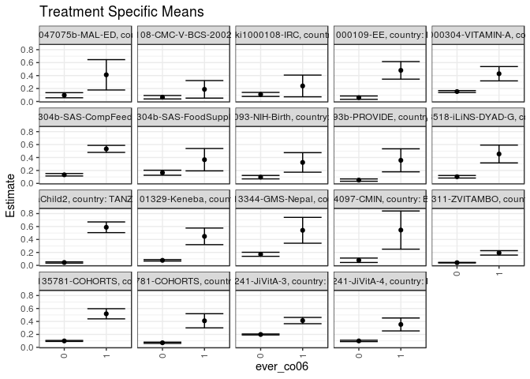

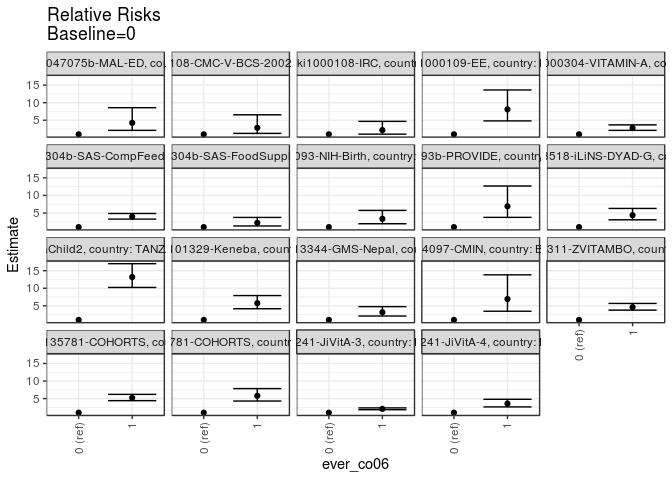

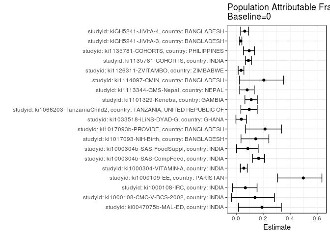

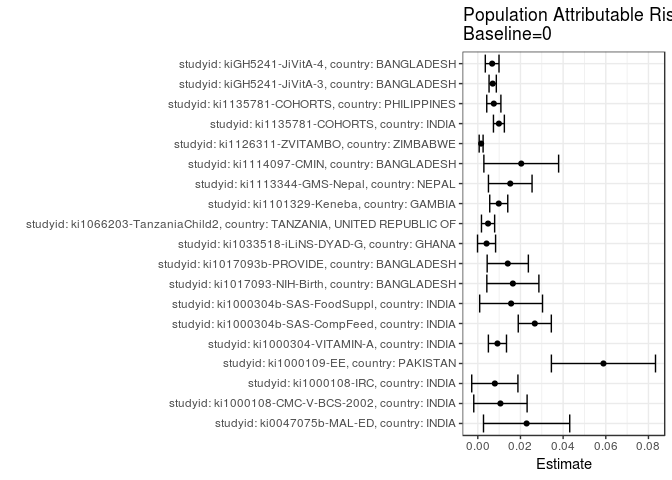

## Results Table

### Parameter: TSM

| studyid | country | intervention_level | baseline_level | estimate | ci_lower | ci_upper |
| --- | --- | --- | --- | --- | --- | --- |
| ki0047075b-MAL-ED | INDIA | 0 | NA | 0.0967742 | 0.0573533 | 0.1361951 |
| ki0047075b-MAL-ED | INDIA | 1 | NA | 0.4117647 | 0.1773128 | 0.6462166 |
| ki1000108-CMC-V-BCS-2002 | INDIA | 0 | NA | 0.0654762 | 0.0389908 | 0.0919616 |
| ki1000108-CMC-V-BCS-2002 | INDIA | 1 | NA | 0.1875000 | 0.0520820 | 0.3229180 |
| ki1000108-IRC | INDIA | 0 | NA | 0.1090909 | 0.0779121 | 0.1402697 |
| ki1000108-IRC | INDIA | 1 | NA | 0.2400000 | 0.0723820 | 0.4076180 |
| ki1000109-EE | PAKISTAN | 0 | NA | 0.0593750 | 0.0334471 | 0.0853029 |
| ki1000109-EE | PAKISTAN | 1 | NA | 0.4807692 | 0.3447878 | 0.6167506 |
| ki1000304-VITAMIN-A | INDIA | 0 | NA | 0.1532584 | 0.1382869 | 0.1682299 |
| ki1000304-VITAMIN-A | INDIA | 1 | NA | 0.4285714 | 0.3180136 | 0.5391293 |
| ki1000304b-SAS-CompFeed | INDIA | 0 | NA | 0.1337580 | 0.1145801 | 0.1529358 |
| ki1000304b-SAS-CompFeed | INDIA | 1 | NA | 0.5333333 | 0.4788565 | 0.5878101 |
| ki1000304b-SAS-FoodSuppl | INDIA | 0 | NA | 0.1652661 | 0.1266879 | 0.2038443 |
| ki1000304b-SAS-FoodSuppl | INDIA | 1 | NA | 0.3666667 | 0.1940029 | 0.5393304 |
| ki1017093-NIH-Birth | BANGLADESH | 0 | NA | 0.0968421 | 0.0702202 | 0.1234641 |
| ki1017093-NIH-Birth | BANGLADESH | 1 | NA | 0.3243243 | 0.1733404 | 0.4753082 |
| ki1017093b-PROVIDE | BANGLADESH | 0 | NA | 0.0516351 | 0.0336266 | 0.0696436 |
| ki1017093b-PROVIDE | BANGLADESH | 1 | NA | 0.3571429 | 0.1795178 | 0.5347679 |
| ki1033518-iLiNS-DYAD-G | GHANA | 0 | NA | 0.1032258 | 0.0833940 | 0.1230576 |
| ki1033518-iLiNS-DYAD-G | GHANA | 1 | NA | 0.4545455 | 0.3168836 | 0.5922073 |
| ki1066203-TanzaniaChild2 | TANZANIA, UNITED REPUBLIC OF | 0 | NA | 0.0446194 | 0.0351918 | 0.0540470 |
| ki1066203-TanzaniaChild2 | TANZANIA, UNITED REPUBLIC OF | 1 | NA | 0.5882353 | 0.5054426 | 0.6710280 |
| ki1101329-Keneba | GAMBIA | 0 | NA | 0.0779709 | 0.0665789 | 0.0893628 |
| ki1101329-Keneba | GAMBIA | 1 | NA | 0.4482759 | 0.3202590 | 0.5762927 |
| ki1113344-GMS-Nepal | NEPAL | 0 | NA | 0.1714286 | 0.1401870 | 0.2026701 |
| ki1113344-GMS-Nepal | NEPAL | 1 | NA | 0.5416667 | 0.3421536 | 0.7411798 |
| ki1114097-CMIN | BANGLADESH | 0 | NA | 0.0788382 | 0.0447472 | 0.1129291 |
| ki1114097-CMIN | BANGLADESH | 1 | NA | 0.5454545 | 0.2506168 | 0.8402923 |
| ki1126311-ZVITAMBO | ZIMBABWE | 0 | NA | 0.0417507 | 0.0374167 | 0.0460847 |
| ki1126311-ZVITAMBO | ZIMBABWE | 1 | NA | 0.1931818 | 0.1590973 | 0.2272663 |
| ki1135781-COHORTS | INDIA | 0 | NA | 0.0990082 | 0.0912747 | 0.1067417 |
| ki1135781-COHORTS | INDIA | 1 | NA | 0.5179856 | 0.4395125 | 0.5964587 |
| ki1135781-COHORTS | PHILIPPINES | 0 | NA | 0.0705009 | 0.0608060 | 0.0801959 |
| ki1135781-COHORTS | PHILIPPINES | 1 | NA | 0.4098361 | 0.3005502 | 0.5191219 |
| kiGH5241-JiVitA-3 | BANGLADESH | 0 | NA | 0.1986331 | 0.1911206 | 0.2061456 |
| kiGH5241-JiVitA-3 | BANGLADESH | 1 | NA | 0.4134199 | 0.3649300 | 0.4619098 |
| kiGH5241-JiVitA-4 | BANGLADESH | 0 | NA | 0.0991617 | 0.0886225 | 0.1097010 |
| kiGH5241-JiVitA-4 | BANGLADESH | 1 | NA | 0.3533835 | 0.2535834 | 0.4531835 |

### Parameter: E(Y)

| studyid | country | intervention_level | baseline_level | estimate | ci_lower | ci_upper |
| --- | --- | --- | --- | --- | --- | --- |
| ki0047075b-MAL-ED | INDIA | NA | NA | 0.1196581 | 0.0779840 | 0.1613323 |
| ki1000108-CMC-V-BCS-2002 | INDIA | NA | NA | 0.0760870 | 0.0489610 | 0.1032130 |
| ki1000108-IRC | INDIA | NA | NA | 0.1170732 | 0.0859146 | 0.1482317 |
| ki1000109-EE | PAKISTAN | NA | NA | 0.1182796 | 0.0854185 | 0.1511406 |
| ki1000304-VITAMIN-A | INDIA | NA | NA | 0.1624674 | 0.1473953 | 0.1775395 |
| ki1000304b-SAS-CompFeed | INDIA | NA | NA | 0.1604755 | 0.1397079 | 0.1812430 |
| ki1000304b-SAS-FoodSuppl | INDIA | NA | NA | 0.1808786 | 0.1424794 | 0.2192777 |
| ki1017093-NIH-Birth | BANGLADESH | NA | NA | 0.1132813 | 0.0858017 | 0.1407608 |
| ki1017093b-PROVIDE | BANGLADESH | NA | NA | 0.0656814 | 0.0459906 | 0.0853723 |
| ki1033518-iLiNS-DYAD-G | GHANA | NA | NA | 0.1073326 | 0.0875449 | 0.1271203 |
| ki1066203-TanzaniaChild2 | TANZANIA, UNITED REPUBLIC OF | NA | NA | 0.0494277 | 0.0397346 | 0.0591208 |
| ki1101329-Keneba | GAMBIA | NA | NA | 0.0877915 | 0.0759284 | 0.0996545 |
| ki1113344-GMS-Nepal | NEPAL | NA | NA | 0.1866438 | 0.1550166 | 0.2182711 |
| ki1114097-CMIN | BANGLADESH | NA | NA | 0.0992063 | 0.0622241 | 0.1361886 |
| ki1126311-ZVITAMBO | ZIMBABWE | NA | NA | 0.0433149 | 0.0389920 | 0.0476379 |
| ki1135781-COHORTS | INDIA | NA | NA | 0.1089025 | 0.1009435 | 0.1168614 |
| ki1135781-COHORTS | PHILIPPINES | NA | NA | 0.0780116 | 0.0679971 | 0.0880261 |
| kiGH5241-JiVitA-3 | BANGLADESH | NA | NA | 0.2056134 | 0.1980359 | 0.2131909 |
| kiGH5241-JiVitA-4 | BANGLADESH | NA | NA | 0.1058917 | 0.0951201 | 0.1166633 |

### Parameter: RR

| studyid | country | intervention_level | baseline_level | estimate | ci_lower | ci_upper |
| --- | --- | --- | --- | --- | --- | --- |
| ki0047075b-MAL-ED | INDIA | 0 | 0 | 1.000000 | 1.000000 | 1.000000 |
| ki0047075b-MAL-ED | INDIA | 1 | 0 | 4.254902 | 2.112725 | 8.569117 |
| ki1000108-CMC-V-BCS-2002 | INDIA | 0 | 0 | 1.000000 | 1.000000 | 1.000000 |
| ki1000108-CMC-V-BCS-2002 | INDIA | 1 | 0 | 2.863636 | 1.251448 | 6.552742 |
| ki1000108-IRC | INDIA | 0 | 0 | 1.000000 | 1.000000 | 1.000000 |
| ki1000108-IRC | INDIA | 1 | 0 | 2.200000 | 1.034411 | 4.678991 |
| ki1000109-EE | PAKISTAN | 0 | 0 | 1.000000 | 1.000000 | 1.000000 |
| ki1000109-EE | PAKISTAN | 1 | 0 | 8.097166 | 4.812593 | 13.623445 |
| ki1000304-VITAMIN-A | INDIA | 0 | 0 | 1.000000 | 1.000000 | 1.000000 |
| ki1000304-VITAMIN-A | INDIA | 1 | 0 | 2.796397 | 2.122271 | 3.684656 |
| ki1000304b-SAS-CompFeed | INDIA | 0 | 0 | 1.000000 | 1.000000 | 1.000000 |
| ki1000304b-SAS-CompFeed | INDIA | 1 | 0 | 3.987302 | 3.268758 | 4.863797 |
| ki1000304b-SAS-FoodSuppl | INDIA | 0 | 0 | 1.000000 | 1.000000 | 1.000000 |
| ki1000304b-SAS-FoodSuppl | INDIA | 1 | 0 | 2.218644 | 1.311686 | 3.752715 |
| ki1017093-NIH-Birth | BANGLADESH | 0 | 0 | 1.000000 | 1.000000 | 1.000000 |
| ki1017093-NIH-Birth | BANGLADESH | 1 | 0 | 3.349001 | 1.950375 | 5.750590 |
| ki1017093b-PROVIDE | BANGLADESH | 0 | 0 | 1.000000 | 1.000000 | 1.000000 |
| ki1017093b-PROVIDE | BANGLADESH | 1 | 0 | 6.916667 | 3.767778 | 12.697212 |
| ki1033518-iLiNS-DYAD-G | GHANA | 0 | 0 | 1.000000 | 1.000000 | 1.000000 |
| ki1033518-iLiNS-DYAD-G | GHANA | 1 | 0 | 4.403409 | 3.076295 | 6.303041 |
| ki1066203-TanzaniaChild2 | TANZANIA, UNITED REPUBLIC OF | 0 | 0 | 1.000000 | 1.000000 | 1.000000 |
| ki1066203-TanzaniaChild2 | TANZANIA, UNITED REPUBLIC OF | 1 | 0 | 13.183391 | 10.227518 | 16.993545 |
| ki1101329-Keneba | GAMBIA | 0 | 0 | 1.000000 | 1.000000 | 1.000000 |
| ki1101329-Keneba | GAMBIA | 1 | 0 | 5.749273 | 4.171570 | 7.923669 |
| ki1113344-GMS-Nepal | NEPAL | 0 | 0 | 1.000000 | 1.000000 | 1.000000 |
| ki1113344-GMS-Nepal | NEPAL | 1 | 0 | 3.159722 | 2.094957 | 4.765655 |
| ki1114097-CMIN | BANGLADESH | 0 | 0 | 1.000000 | 1.000000 | 1.000000 |
| ki1114097-CMIN | BANGLADESH | 1 | 0 | 6.918660 | 3.462552 | 13.824446 |
| ki1126311-ZVITAMBO | ZIMBABWE | 0 | 0 | 1.000000 | 1.000000 | 1.000000 |
| ki1126311-ZVITAMBO | ZIMBABWE | 1 | 0 | 4.627034 | 3.770494 | 5.678152 |
| ki1135781-COHORTS | INDIA | 0 | 0 | 1.000000 | 1.000000 | 1.000000 |
| ki1135781-COHORTS | INDIA | 1 | 0 | 5.231746 | 4.411864 | 6.203990 |
| ki1135781-COHORTS | PHILIPPINES | 0 | 0 | 1.000000 | 1.000000 | 1.000000 |
| ki1135781-COHORTS | PHILIPPINES | 1 | 0 | 5.813201 | 4.306406 | 7.847217 |
| kiGH5241-JiVitA-3 | BANGLADESH | 0 | 0 | 1.000000 | 1.000000 | 1.000000 |
| kiGH5241-JiVitA-3 | BANGLADESH | 1 | 0 | 2.081324 | 1.843678 | 2.349602 |
| kiGH5241-JiVitA-4 | BANGLADESH | 0 | 0 | 1.000000 | 1.000000 | 1.000000 |
| kiGH5241-JiVitA-4 | BANGLADESH | 1 | 0 | 3.563708 | 2.643041 | 4.805077 |

### Parameter: PAR

| studyid | country | intervention_level | baseline_level | estimate | ci_lower | ci_upper |
| --- | --- | --- | --- | --- | --- | --- |
| ki0047075b-MAL-ED | INDIA | 0 | NA | 0.0228839 | 0.0026719 | 0.0430960 |
| ki1000108-CMC-V-BCS-2002 | INDIA | 0 | NA | 0.0106108 | -0.0018928 | 0.0231144 |
| ki1000108-IRC | INDIA | 0 | NA | 0.0079823 | -0.0028479 | 0.0188124 |
| ki1000109-EE | PAKISTAN | 0 | NA | 0.0589046 | 0.0345010 | 0.0833081 |
| ki1000304-VITAMIN-A | INDIA | 0 | NA | 0.0092090 | 0.0049643 | 0.0134537 |
| ki1000304b-SAS-CompFeed | INDIA | 0 | NA | 0.0267175 | 0.0189642 | 0.0344709 |
| ki1000304b-SAS-FoodSuppl | INDIA | 0 | NA | 0.0156124 | 0.0008828 | 0.0303421 |
| ki1017093-NIH-Birth | BANGLADESH | 0 | NA | 0.0164391 | 0.0042395 | 0.0286388 |
| ki1017093b-PROVIDE | BANGLADESH | 0 | NA | 0.0140463 | 0.0043899 | 0.0237028 |
| ki1033518-iLiNS-DYAD-G | GHANA | 0 | NA | 0.0041068 | -0.0001261 | 0.0083397 |
| ki1066203-TanzaniaChild2 | TANZANIA, UNITED REPUBLIC OF | 0 | NA | 0.0048083 | 0.0017227 | 0.0078938 |
| ki1101329-Keneba | GAMBIA | 0 | NA | 0.0098206 | 0.0055970 | 0.0140442 |
| ki1113344-GMS-Nepal | NEPAL | 0 | NA | 0.0152153 | 0.0049943 | 0.0254362 |
| ki1114097-CMIN | BANGLADESH | 0 | NA | 0.0203682 | 0.0028480 | 0.0378883 |
| ki1126311-ZVITAMBO | ZIMBABWE | 0 | NA | 0.0015643 | 0.0006458 | 0.0024827 |
| ki1135781-COHORTS | INDIA | 0 | NA | 0.0098943 | 0.0073393 | 0.0124493 |
| ki1135781-COHORTS | PHILIPPINES | 0 | NA | 0.0075107 | 0.0041943 | 0.0108271 |
| kiGH5241-JiVitA-3 | BANGLADESH | 0 | NA | 0.0069803 | 0.0052762 | 0.0086843 |
| kiGH5241-JiVitA-4 | BANGLADESH | 0 | NA | 0.0067300 | 0.0035195 | 0.0099405 |

### Parameter: PAF

| studyid | country | intervention_level | baseline_level | estimate | ci_lower | ci_upper |
| --- | --- | --- | --- | --- | --- | --- |
| ki0047075b-MAL-ED | INDIA | 0 | NA | 0.1912442 | 0.0163422 | 0.3350473 |
| ki1000108-CMC-V-BCS-2002 | INDIA | 0 | NA | 0.1394558 | -0.0336740 | 0.2835881 |
| ki1000108-IRC | INDIA | 0 | NA | 0.0681818 | -0.0275834 | 0.1550223 |
| ki1000109-EE | PAKISTAN | 0 | NA | 0.4980114 | 0.3078452 | 0.6359303 |
| ki1000304-VITAMIN-A | INDIA | 0 | NA | 0.0566821 | 0.0305374 | 0.0821217 |
| ki1000304b-SAS-CompFeed | INDIA | 0 | NA | 0.1664897 | 0.1205542 | 0.2100260 |
| ki1000304b-SAS-FoodSuppl | INDIA | 0 | NA | 0.0863145 | 0.0024951 | 0.1630907 |
| ki1017093-NIH-Birth | BANGLADESH | 0 | NA | 0.1451180 | 0.0355449 | 0.2422423 |
| ki1017093b-PROVIDE | BANGLADESH | 0 | NA | 0.2138554 | 0.0677466 | 0.3370651 |
| ki1033518-iLiNS-DYAD-G | GHANA | 0 | NA | 0.0382625 | -0.0019422 | 0.0768540 |
| ki1066203-TanzaniaChild2 | TANZANIA, UNITED REPUBLIC OF | 0 | NA | 0.0972786 | 0.0345346 | 0.1559450 |
| ki1101329-Keneba | GAMBIA | 0 | NA | 0.1118630 | 0.0645469 | 0.1567857 |
| ki1113344-GMS-Nepal | NEPAL | 0 | NA | 0.0815203 | 0.0261723 | 0.1337226 |
| ki1114097-CMIN | BANGLADESH | 0 | NA | 0.2053112 | 0.0251928 | 0.3521485 |
| ki1126311-ZVITAMBO | ZIMBABWE | 0 | NA | 0.0361137 | 0.0147085 | 0.0570538 |
| ki1135781-COHORTS | INDIA | 0 | NA | 0.0908547 | 0.0678207 | 0.1133195 |
| ki1135781-COHORTS | PHILIPPINES | 0 | NA | 0.0962765 | 0.0542642 | 0.1364225 |
| kiGH5241-JiVitA-3 | BANGLADESH | 0 | NA | 0.0339485 | 0.0257202 | 0.0421073 |
| kiGH5241-JiVitA-4 | BANGLADESH | 0 | NA | 0.0635554 | 0.0335107 | 0.0926661 |